# Loan Data Exploration

## Preliminary Wrangling

This document explores a dataset containing 113,937 loans with 81 variables on each loan, including loan amount, borrower rate (or interest rate), current loan status, borrower income, and many others.

```python
# import all packages and set plots to be embedded inline
import numpy as np
import pandas as pd
import matplotlib.pyplot as plt
import seaborn as sb

%matplotlib inline
```

## Load in the dataset and describe its general Properties

```python
# load in the dataset into a pandas dataframe
df_all = pd.read_csv('prosperLoanData.csv')
df_all.head()
```

|  | ListingKey | ListingNumber | ListingCreationDate | CreditGrade | Term | LoanStatus | ClosedDate | BorrowerAPR | BorrowerRate | LenderYield | ... | LP_ServiceFees | LP_CollectionFees | LP_GrossPrincipalLoss | LP_NetPrincipalLoss | LP_NonPrincipalRecoverypayments | PercentFunded | Recommendations | InvestmentFromFriendsCount | InvestmentFromFriendsAmount | Investors |
| --- | --- | --- | --- | --- | --- | --- | --- | --- | --- | --- | --- | --- | --- | --- | --- | --- | --- | --- | --- | --- | --- |
| 0 | 1021339766868145413AB3B | 193129 | 2007-08-26 19:09:29.263000000 | C | 36 | Completed | 2009-08-14 00:00:00 | 0.16516 | 0.1580 | 0.1380 | ... | -133.18 | 0.0 | 0.0 | 0.0 | 0.0 | 1.0 | 0 | 0 | 0.0 | 258 |
| 1 | 10273602499503308B223C1 | 1209647 | 2014-02-27 08:28:07.900000000 | NaN | 36 | Current | NaN | 0.12016 | 0.0920 | 0.0820 | ... | 0.00 | 0.0 | 0.0 | 0.0 | 0.0 | 1.0 | 0 | 0 | 0.0 | 1 |
| 2 | 0EE9337825851032864889A | 81716 | 2007-01-05 15:00:47.090000000 | HR | 36 | Completed | 2009-12-17 00:00:00 | 0.28269 | 0.2750 | 0.2400 | ... | -24.20 | 0.0 | 0.0 | 0.0 | 0.0 | 1.0 | 0 | 0 | 0.0 | 41 |
| 3 | 0EF5356002482715299901A | 658116 | 2012-10-22 11:02:35.010000000 | NaN | 36 | Current | NaN | 0.12528 | 0.0974 | 0.0874 | ... | -108.01 | 0.0 | 0.0 | 0.0 | 0.0 | 1.0 | 0 | 0 | 0.0 | 158 |
| 4 | 0F023589499656230C5E3E2 | 909464 | 2013-09-14 18:38:39.097000000 | NaN | 36 | Current | NaN | 0.24614 | 0.2085 | 0.1985 | ... | -60.27 | 0.0 | 0.0 | 0.0 | 0.0 | 1.0 | 0 | 0 | 0.0 | 20 |

5 rows × 81 columns

```python
df_all.info()
```

```
<class 'pandas.core.frame.DataFrame'>
RangeIndex: 113937 entries, 0 to 113936
Data columns (total 81 columns):
 #   Column                               Non-Null Count   Dtype
---  ------                               --------------   -----
 0   ListingKey                           113937 non-null  object
 1   ListingNumber                        113937 non-null  int64
 2   ListingCreationDate                  113937 non-null  object
 3   CreditGrade                          28953 non-null   object
 4   Term                                 113937 non-null  int64
 5   LoanStatus                           113937 non-null  object
 6   ClosedDate                           55089 non-null   object
 7   BorrowerAPR                          113912 non-null  float64
 8   BorrowerRate                         113937 non-null  float64
 9   LenderYield                          113937 non-null  float64
```

[output cut: 73 more lines]

```python
# Selecting features of interest

col = ['LoanOriginalAmount', 'BorrowerAPR' , 'EmploymentStatus', 'EmploymentStatusDuration',
       'Term', 'MonthlyLoanPayment'  , 'StatedMonthlyIncome' , 'ProsperScore',
        'IsBorrowerHomeowner' ,  'AvailableBankcardCredit', 'Recommendations']

df = df_all[col]
df.head()
```

|  | LoanOriginalAmount | BorrowerAPR | EmploymentStatus | EmploymentStatusDuration | Term | MonthlyLoanPayment | StatedMonthlyIncome | ProsperScore | IsBorrowerHomeowner | AvailableBankcardCredit | Recommendations |
| --- | --- | --- | --- | --- | --- | --- | --- | --- | --- | --- | --- |
| 0 | 9425 | 0.16516 | Self-employed | 2.0 | 36 | 330.43 | 3083.333333 | NaN | True | 1500.0 | 0 |
| 1 | 10000 | 0.12016 | Employed | 44.0 | 36 | 318.93 | 6125.000000 | 7.0 | False | 10266.0 | 0 |
| 2 | 3001 | 0.28269 | Not available | NaN | 36 | 123.32 | 2083.333333 | NaN | False | NaN | 0 |
| 3 | 10000 | 0.12528 | Employed | 113.0 | 36 | 321.45 | 2875.000000 | 9.0 | True | 30754.0 | 0 |
| 4 | 15000 | 0.24614 | Employed | 44.0 | 36 | 563.97 | 9583.333333 | 4.0 | True | 695.0 | 0 |

```python
# high-level overview of data structure
print(df.shape)
print(df.nunique())
```

```
(113937, 11)
LoanOriginalAmount           2468
BorrowerAPR                  6677
EmploymentStatus                8
EmploymentStatusDuration      605
Term                            3
MonthlyLoanPayment          23567
StatedMonthlyIncome         13502
ProsperScore                   11
IsBorrowerHomeowner             2
AvailableBankcardCredit     31829
Recommendations                17
dtype: int64
```

```python
# descriptive statistics for numeric variables
df.describe()
```

|  | LoanOriginalAmount | BorrowerAPR | EmploymentStatusDuration | Term | MonthlyLoanPayment | StatedMonthlyIncome | ProsperScore | AvailableBankcardCredit | Recommendations |
| --- | --- | --- | --- | --- | --- | --- | --- | --- | --- |
| count | 113937.00000 | 113912.000000 | 106312.000000 | 113937.000000 | 113937.000000 | 1.139370e+05 | 84853.000000 | 106393.000000 | 113937.000000 |
| mean | 8337.01385 | 0.218828 | 96.071582 | 40.830248 | 272.475783 | 5.608026e+03 | 5.950067 | 11210.225447 | 0.048027 |
| std | 6245.80058 | 0.080364 | 94.480605 | 10.436212 | 192.697812 | 7.478497e+03 | 2.376501 | 19818.361309 | 0.332353 |
| min | 1000.00000 | 0.006530 | 0.000000 | 12.000000 | 0.000000 | 0.000000e+00 | 1.000000 | 0.000000 | 0.000000 |
| 25% | 4000.00000 | 0.156290 | 26.000000 | 36.000000 | 131.620000 | 3.200333e+03 | 4.000000 | 880.000000 | 0.000000 |
| 50% | 6500.00000 | 0.209760 | 67.000000 | 36.000000 | 217.740000 | 4.666667e+03 | 6.000000 | 4100.000000 | 0.000000 |
| 75% | 12000.00000 | 0.283810 | 137.000000 | 36.000000 | 371.580000 | 6.825000e+03 | 8.000000 | 13180.000000 | 0.000000 |
| max | 35000.00000 | 0.512290 | 755.000000 | 60.000000 | 2251.510000 | 1.750003e+06 | 11.000000 | 646285.000000 | 39.000000 |

## Cleaning Data

```python
# number of duplicates

print(df.duplicated().sum())
print(df.shape)
```

```
110
(113937, 11)
```

```python
# Remove duplicated rows.

df=df.drop(df[df.duplicated()].index)
print(df.duplicated().sum())
print(df.shape)
```

```
0
(113827, 11)
```

```python
# Remove rows with null values.

df=df.dropna()
df.isnull().sum(1).sum()
```

```
0
```

```python
df.head()
```

|  | LoanOriginalAmount | BorrowerAPR | EmploymentStatus | EmploymentStatusDuration | Term | MonthlyLoanPayment | StatedMonthlyIncome | ProsperScore | IsBorrowerHomeowner | AvailableBankcardCredit | Recommendations |
| --- | --- | --- | --- | --- | --- | --- | --- | --- | --- | --- | --- |
| 1 | 10000 | 0.12016 | Employed | 44.0 | 36 | 318.93 | 6125.000000 | 7.0 | False | 10266.0 | 0 |
| 3 | 10000 | 0.12528 | Employed | 113.0 | 36 | 321.45 | 2875.000000 | 9.0 | True | 30754.0 | 0 |
| 4 | 15000 | 0.24614 | Employed | 44.0 | 36 | 563.97 | 9583.333333 | 4.0 | True | 695.0 | 0 |
| 5 | 15000 | 0.15425 | Employed | 82.0 | 60 | 342.37 | 8333.333333 | 10.0 | True | 86509.0 | 0 |
| 6 | 3000 | 0.31032 | Employed | 172.0 | 36 | 122.67 | 2083.333333 | 2.0 | False | 1929.0 | 0 |

```python
# descriptive statistics for numeric variables
df.describe()
```

|  | LoanOriginalAmount | BorrowerAPR | EmploymentStatusDuration | Term | MonthlyLoanPayment | StatedMonthlyIncome | ProsperScore | AvailableBankcardCredit | Recommendations |
| --- | --- | --- | --- | --- | --- | --- | --- | --- | --- |
| count | 84831.000000 | 84831.000000 | 84831.000000 | 84831.000000 | 84831.000000 | 8.483100e+04 | 84831.000000 | 84831.000000 | 84831.000000 |
| mean | 9084.116396 | 0.226651 | 103.057927 | 42.486968 | 291.949557 | 5.931440e+03 | 5.950148 | 11402.248235 | 0.017541 |
| std | 6287.719087 | 0.079916 | 97.079451 | 11.640985 | 186.678100 | 8.240803e+03 | 2.376513 | 18611.970992 | 0.187927 |
| min | 1000.000000 | 0.045830 | 0.000000 | 12.000000 | 0.000000 | 0.000000e+00 | 1.000000 | 0.000000 | 0.000000 |
| 25% | 4000.000000 | 0.163280 | 30.000000 | 36.000000 | 157.330000 | 3.440167e+03 | 4.000000 | 1148.000000 | 0.000000 |
| 50% | 7500.000000 | 0.219450 | 74.000000 | 36.000000 | 251.960000 | 5.000000e+03 | 6.000000 | 4576.000000 | 0.000000 |
| 75% | 13500.000000 | 0.292540 | 148.000000 | 60.000000 | 388.350000 | 7.083333e+03 | 8.000000 | 13913.000000 | 0.000000 |
| max | 35000.000000 | 0.423950 | 755.000000 | 60.000000 | 2251.510000 | 1.750003e+06 | 11.000000 | 498374.000000 | 19.000000 |

```python
df.info()
```

```
<class 'pandas.core.frame.DataFrame'>
Int64Index: 84831 entries, 1 to 113936
Data columns (total 11 columns):
 #   Column                    Non-Null Count  Dtype
---  ------                    --------------  -----
 0   LoanOriginalAmount        84831 non-null  int64
 1   BorrowerAPR               84831 non-null  float64
 2   EmploymentStatus          84831 non-null  object
 3   EmploymentStatusDuration  84831 non-null  float64
 4   Term                      84831 non-null  int64
 5   MonthlyLoanPayment        84831 non-null  float64
 6   StatedMonthlyIncome       84831 non-null  float64
 7   ProsperScore              84831 non-null  float64
 8   IsBorrowerHomeowner       84831 non-null  bool
 9   AvailableBankcardCredit   84831 non-null  float64
 10  Recommendations           84831 non-null  int64
dtypes: bool(1), float64(6), int64(3), object(1)
memory usage: 7.2+ MB
```

### What is the structure of your dataset?

This document explores a dataset containing 113,937 loans with 81 variables on each loan, including loan amount, borrower rate (or interest rate), current loan status, borrower income, and many others.

### What features in the dataset do you think will help support your investigation into your feature(s) of interest?

I think features like: ( EmploymentStatusDuration - Term - MonthlyLoanPayment - StatedMonthlyIncome - ProsperScore - IsBorrowerHomeowner - AvailableBankcardCredit - Recommendations) will have a grear effect on my investigation

## Univariate Exploration

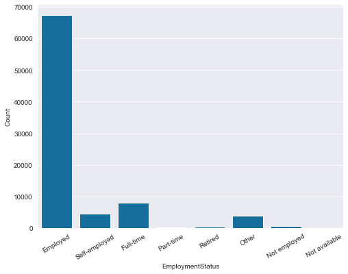

```python
# the distribution of the loan’s outcome status.

order = ['Employed','Self-employed','Full-time','Part-time','Retired','Other','Not employed', 'Not available']


plt.rcParams['figure.figsize'] = 8, 6
base_c = sb.color_palette('colorblind')[0]
sb.set_style('darkgrid')

sb.countplot(data=df, x='EmploymentStatus', color=base_c ,order = order );
plt.xticks(rotation=30);
plt.ylabel('Count');
```

Most of loans are taken by employed.

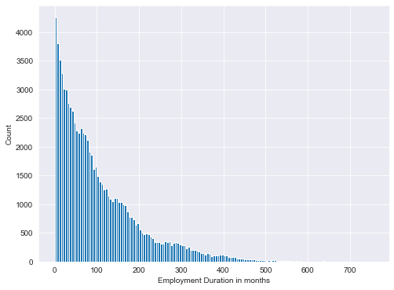

```python
# the distribution of the Employment Duration.

plt.figure(figsize=[8, 6])
bins = np.arange(0, df['EmploymentStatusDuration'].max()+5, 5)

plt.hist(df['EmploymentStatusDuration'], bins=bins);
plt.xlabel('Employment Duration in months');
plt.ylabel('Count');
```

It was surprising to see that Employment Duration is inversely proportional with the number of loans

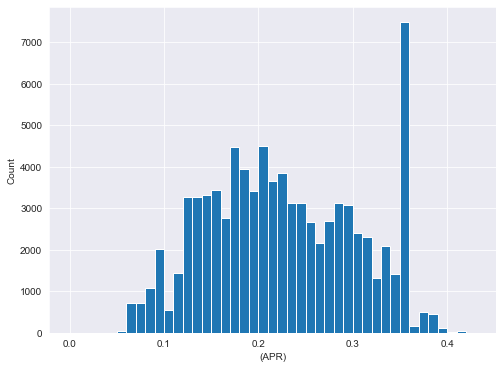

```python
# the distribution of the borrower's Annual Percentage Rate (APR)


plt.figure(figsize=[8, 6])
bins = np.arange(0, df['BorrowerAPR'].max()+0.01, 0.01)

plt.hist(df['BorrowerAPR'], bins=bins);
plt.xlabel('(APR)');
plt.ylabel('Count');
```

The distribution of APR has a large peak around 0.2, then a smaller one around 0.28

Also, there is a very high number of loans (more than 7000) with APR between 0.34 and 0.36.

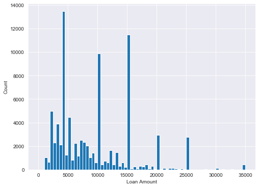

```python
# the distribution of Loan Original Amount

plt.figure(figsize=[8, 6])
bins = np.arange(0, df['LoanOriginalAmount'].max()+500, 500)

plt.hist(df['LoanOriginalAmount'], bins=bins);
plt.xlabel('Loan Amount');
plt.ylabel('Count');
```

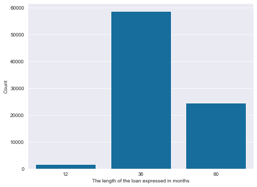

```python
# the distribution of The length of the loan expressed in months.

base_c = sb.color_palette('colorblind')[0]
sb.countplot(data = df, x = 'Term', color = base_c);
plt.xlabel('The length of the loan expressed in months');
plt.ylabel('Count');
```

Most loans length were 36 months long.

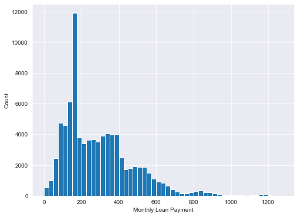

```python
# the distribution of Monthly Loan Payment

plt.figure(figsize=[8, 6])
bins = np.arange(0, 1300, 25)

plt.hist(df['MonthlyLoanPayment'], bins=bins);
plt.xlabel('Monthly Loan Payment');
plt.ylabel('Count');
```

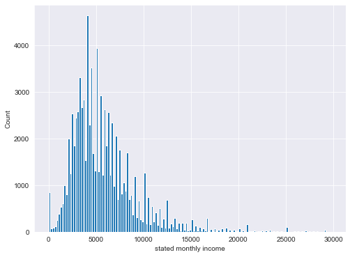

```python
# the distribution of stated monthly income

plt.figure(figsize=[8, 6])
bins = np.arange(0, 30000, 200)

plt.hist(df['StatedMonthlyIncome'] , bins=bins );

plt.xlabel('stated monthly income');
plt.ylabel('Count');
```

Most of loans are taken by the borrowers with monthly income around 5000

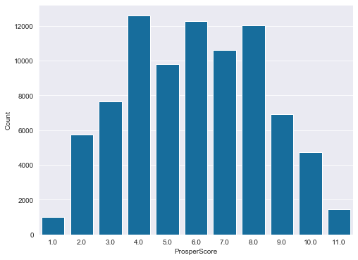

```python
# the distribution of ProsperScore


base_c = sb.color_palette('colorblind')[0]
sb.countplot(data = df, x = 'ProsperScore', color = base_c);
plt.xlabel('ProsperScore');
plt.ylabel('Count');
```

The ProsperScore of most of the loans is between 4 and 8.

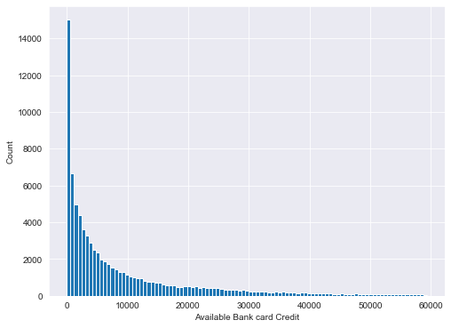

```python
# the distribution of Available Bank card Credit


plt.figure(figsize=[8, 6])
bins = np.arange(0, 60000, 600)
plt.hist(df['AvailableBankcardCredit'], bins=bins);
plt.xlabel('Available Bank card Credit');
plt.ylabel('Count');
```

Available Bank card Credit is inversely proportional with the number of loans

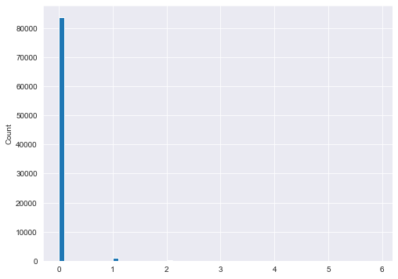

```python
# the distribution of Recommendations


plt.figure(figsize=[8, 6])
bins = np.arange(0, 6, 0.1)
plt.hist(df['Recommendations'] ,bins = bins  );

plt.ylabel('Count');
```

It was surprising to see that more than 90% of loans without any Recommendations.

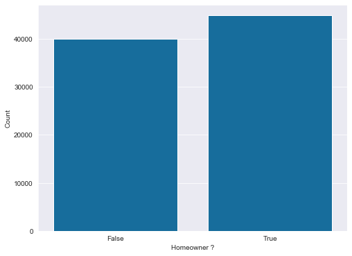

```python
# the distribution of Homeowners

df['IsBorrowerHomeowner'] = df['IsBorrowerHomeowner'].astype('category')
base_c = sb.color_palette('colorblind')[0]
sb.countplot(data = df, x = 'IsBorrowerHomeowner', color = base_c);
plt.xlabel('Homeowner ?');
plt.ylabel('Count');
```

It seems that being a Homeowner has no effect as both distributions nearly the same

[figure not shown]

```python
# Summery

# split data to numerical and categorical data
df_num = df[['LoanOriginalAmount', 'BorrowerAPR', 'EmploymentStatusDuration',
        'MonthlyLoanPayment'  , 'StatedMonthlyIncome' , 'ProsperScore',
        'AvailableBankcardCredit', 'Recommendations']]

# plotting
bins = np.arange(0, 60000, 600)
df_num.hist(figsize=[16, 12] , bins = bins);
```

### Discuss the distribution(s) of your variable(s) of interest. Were there any unusual points? Did you need to perform any transformations?

## I found that:

Most of loans are taken by employed.

Employment Duration is inversely proportional with the number of loans.

The distribution of APR has a large peak around 0.2, then a smaller one around 0.28 and there is a very high number of loans (more than 7000) with APR between 0.34 and 0.36.

Most loans length were 36 months.

Most of loans are taken by the borrowers with monthly income around 5000

The ProsperScore of most of the loans is between 4 and 8.

Available Bank card Credit is inversely proportional with the number of loans

More than 90% of loans without any Recommendations

Being a Homeowner has no effect as both distributions nearly the same

### Of the features you investigated, were there any unusual distributions? Did you perform any operations on the data to tidy, adjust, or change the form of the data? If so, why did you do this?

The distribution of (the Monthly Loan Payment , stated monthly income and Available Bank card Credit) was surprising at the first plotting.Then by using a smaller range (to zoom in and remove unusual points from plots), the distribution became much better.

## Bivariate Exploration

```python
df_num.head()
```

|  | LoanOriginalAmount | BorrowerAPR | EmploymentStatusDuration | MonthlyLoanPayment | StatedMonthlyIncome | ProsperScore | AvailableBankcardCredit | Recommendations |
| --- | --- | --- | --- | --- | --- | --- | --- | --- |
| 1 | 10000 | 0.12016 | 44.0 | 318.93 | 6125.000000 | 7.0 | 10266.0 | 0 |
| 3 | 10000 | 0.12528 | 113.0 | 321.45 | 2875.000000 | 9.0 | 30754.0 | 0 |
| 4 | 15000 | 0.24614 | 44.0 | 563.97 | 9583.333333 | 4.0 | 695.0 | 0 |
| 5 | 15000 | 0.15425 | 82.0 | 342.37 | 8333.333333 | 10.0 | 86509.0 | 0 |
| 6 | 3000 | 0.31032 | 172.0 | 122.67 | 2083.333333 | 2.0 | 1929.0 | 0 |

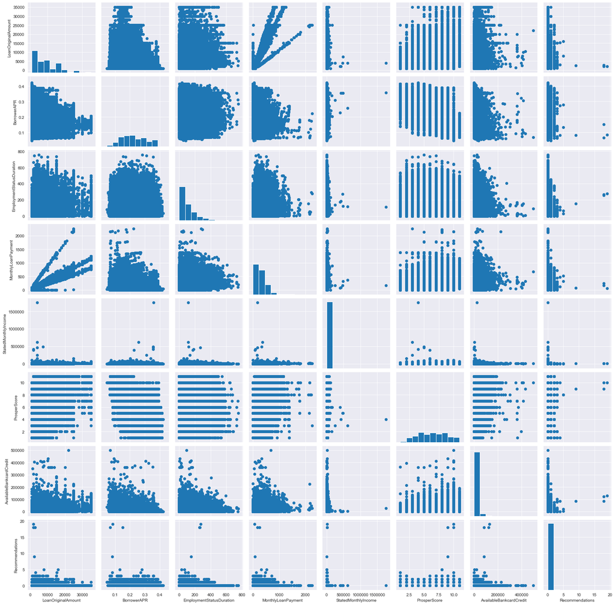

```python
# plotting numeric features against numeric features.

g = sb.PairGrid(data = df_num);
g = g.map_offdiag(plt.scatter);
g.map_diag(plt.hist)
```

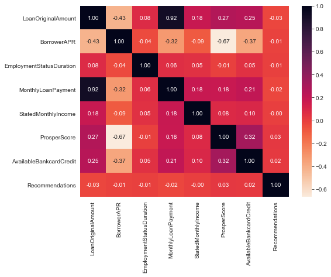

```python
sb.heatmap(df_num.corr(), cmap = 'rocket_r', annot = True , fmt = '.2f');
```

## It seems that:

### there is a positive correlation between:

LoanOriginalAmount - MonthlyLoanPayment

LoanOriginalAmount - ProsperScore

LoanOriginalAmount - AvailableBankcardCredit

### there is a negative correlation between:

BorrowerAPR - LoanOriginalAmount

BorrowerAPR - MonthlyLoanPayment

BorrowerAPR - ProsperScore

BorrowerAPR - AvailableBankcardCredit

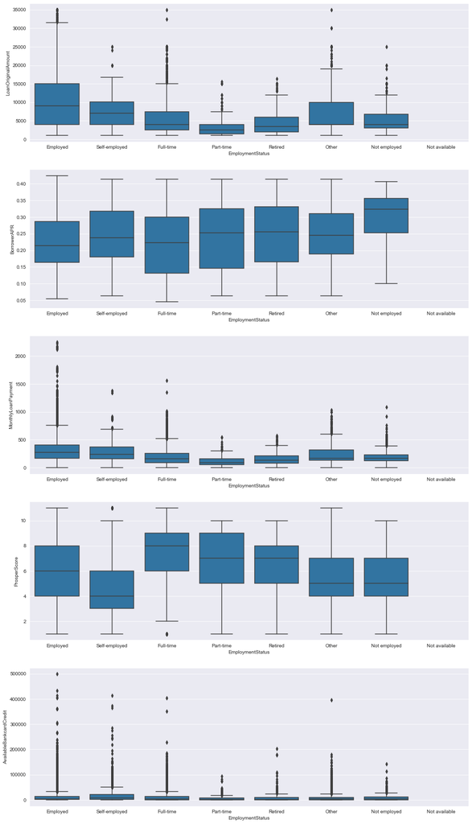

```python
# plotting categorical feature(EmploymentStatus) against numeric features.

order = ['Employed','Self-employed','Full-time','Part-time','Retired','Other','Not employed', 'Not available']

plt.figure(figsize = [16 , 30])
plt.subplot(5, 1, 1)
base_c = sb.color_palette()[0]
sb.boxplot(data = df , x = 'EmploymentStatus' , y =  'LoanOriginalAmount', color = base_c , order = order)

plt.subplot(5, 1, 2)
sb.boxplot(data = df , x = 'EmploymentStatus' , y =  'BorrowerAPR', color = base_c  , order = order)


plt.subplot(5, 1, 3)
sb.boxplot(data = df , x = 'EmploymentStatus' , y =  'MonthlyLoanPayment', color = base_c  , order = order)

plt.subplot(5, 1,4)
sb.boxplot(data = df , x = 'EmploymentStatus' , y =  'ProsperScore', color = base_c  , order = order)


plt.subplot(5, 1, 5)
sb.boxplot(data = df , x = 'EmploymentStatus' , y =  'AvailableBankcardCredit', color = base_c  , order = order)
```

## observation:

Employed persons: has the largest LoanOriginalAmount

Not-employed persons: has the largest BorrowerAPR

The differences in MonthlyLoanPayment are relatively small

Full time jobs have the greatest ProsperScore

The differences in AvailableBankcardCredit are relatively small, although there are many extreme values

### Talk about some of the relationships you observed in this part of the investigation. How did the feature(s) of interest vary with other features in the dataset?

There is a negative correlation between: BorrowerAPR - LoanOriginalAmount

There is a very high positive correlation between: LoanOriginalAmount - MonthlyLoanPayment

There is a very high negative correlation between: BorrowerAPR - ProsperScore

Employed persons: has the largest LoanOriginalAmount

### Did you observe any interesting relationships between the other features (not the main feature(s) of interest)?

Yes, There was a positive correlation between:

ProsperScore - MonthlyLoanPayment

ProsperScore - AvailableBankcardCredit

## Multivariate Exploration

> Create plots of three or more variables to investigate your data even further. Make sure that your investigations are justified, and follow from your work in the previous sections.

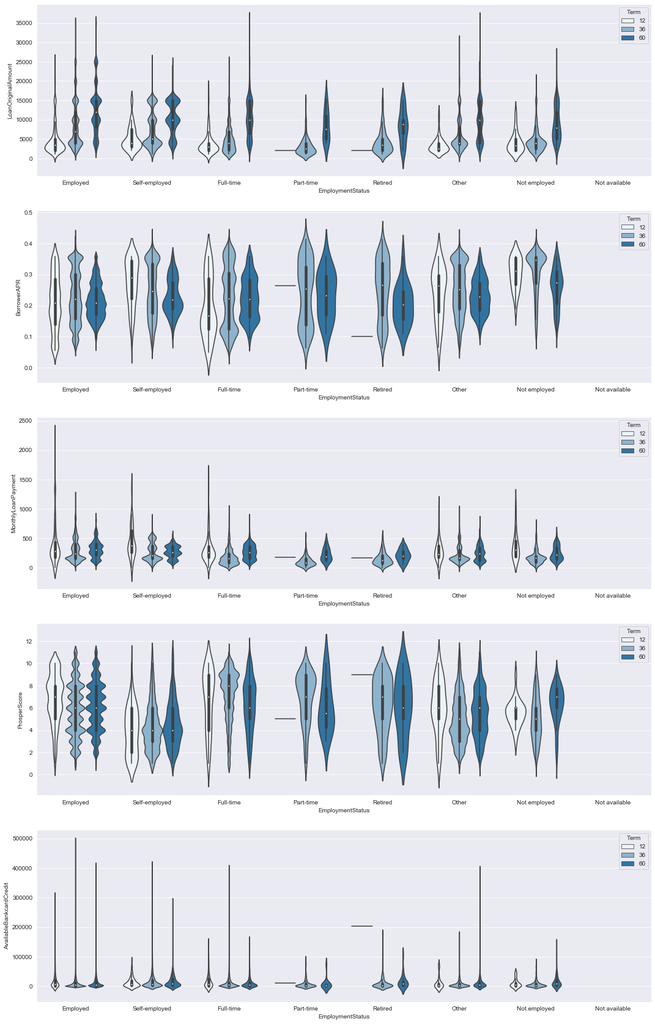

```python
# plotting categorical feature(EmploymentStatus) against numeric features.

plt.figure(figsize = [18 , 30])
plt.subplot(5, 1, 1)
base_c = sb.color_palette()[0]
sb.violinplot(data = df , x = 'EmploymentStatus' , y =  'LoanOriginalAmount', color = base_c , hue = 'Term'  , order = order)

plt.subplot(5, 1, 2)
sb.violinplot(data = df , x = 'EmploymentStatus' , y =  'BorrowerAPR', color = base_c , hue = 'Term'  , order = order)


plt.subplot(5, 1, 3)
sb.violinplot(data = df , x = 'EmploymentStatus' , y =  'MonthlyLoanPayment', color = base_c , hue = 'Term' , order = order)

plt.subplot(5, 1,4)
sb.violinplot(data = df , x = 'EmploymentStatus' , y =  'ProsperScore', color = base_c , hue = 'Term' , order = order)


plt.subplot(5, 1, 5)
sb.violinplot(data = df , x = 'EmploymentStatus' , y =  'AvailableBankcardCredit', color = base_c , hue = 'Term' , order = order)
```

## observation:

12-month LoanOriginalAmount nearly the same for all EmploymentStatus

number of months is directly proportional with LoanOriginalAmount for all EmploymentStatus

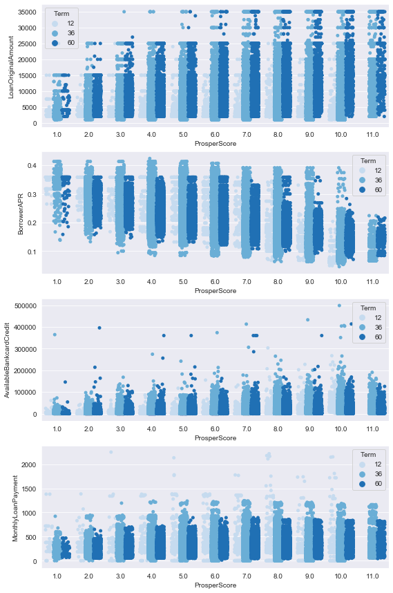

```python
# Which loans has the best ProsperScore ?
df['Term'] = df['Term'].astype('category')

plt.figure(figsize = [9 , 15])

plt.subplot(4, 1, 1)
sb.stripplot(data=df, x='ProsperScore', y='LoanOriginalAmount', hue='Term',
              palette = 'Blues',dodge=0.3, jitter = 0.35);

plt.subplot(4, 1, 2)
sb.stripplot(data = df, x = 'ProsperScore' , y = 'BorrowerAPR' , hue = 'Term',
              palette = 'Blues',dodge=0.3, jitter = 0.35);

plt.subplot(4, 1, 3)
df['Term'] = df['Term'].astype('category')
sb.stripplot(data=df, x='ProsperScore', y='AvailableBankcardCredit', hue='Term',
              palette = 'Blues',dodge=0.3, jitter = 0.35);

plt.subplot(4, 1, 4)
sb.stripplot(data = df, x = 'ProsperScore' , y = 'MonthlyLoanPayment', hue = 'Term',
              palette = 'Blues',dodge=0.3, jitter = 0.35);
```

## observation:

ProsperScore is not affected by: the number of months

ProsperScore is directly proportional with: LoanOriginalAmount - AvailableBankcardCredit

ProsperScore is inversely proportional with: BorrowerAPR

Number of months is inversely proportional with: BorrowerAPR

### Talk about some of the relationships you observed in this part of the investigation. Were there features that strengthened each other in terms of looking at your feature(s) of interest?

The best ProsperScore is with high (LoanOriginalAmount - AvailableBankcardCredit) and low (BorrowerAPR)

### Were there any interesting or surprising interactions between features?

Yes, the MonthlyLoanPayment is directly proportional with the ProsperScore for both 36 and 60 months, but it's nearly constan for 12 months